# Project: Investigate a Dataset - Medical Appointment No Shows

- Introduction
- Data Wrangling
- Exploratory Data Analysis
- Conclusions

## Introduction

### Dataset Description

> **Context**: A person makes a doctor appointment, receives all the instructions and no-show. Who to blame?

> **Content**: 110.527 medical appointments its 14 associated variables (characteristics).  
> The most important one if the patient show-up or no-show to the appointment.  
> Scholarship variable means this concept.  
> There are 14 variables.

> **Data Dictionary**:

> | 01 - PatientId | Identification of a patient |
> | --- | --- |
> | 02 - AppointmentID | Identification of each appointment |
> | 03 - Gender | Male or Female. Female is the greater proportion, woman takes way more care of their health in comparison to man. |
> | 04 - DataMarcacaoConsulta | The day of the actual appointment, when they have to visit the doctor. |
> | 05 - DataAgendamento | The day someone called or registered the appointment, this is before the appointment, of course. |
> | 06 - Age | How old is the patient. |
> | 07 - Neighbourhood | Where the appointment takes place. |
> | 08 - Scholarship | True or False. Observation, this is a broad topic, consider reading this article [Bolsa Família](https://en.wikipedia.org/wiki/Bolsa_Fam%C3%ADlia). |
> | 09 - Hipertension | True or False. |
> | 10 - Diabetes | True or False. |
> | 11 - Alcoholism | True or False. |
> | 12 - Handicap | True or False. |
> | 13 - SMS_received | 1 or more messages sent to the patient. |
> | 14 - No-show | True or False. |

### Effectiveness of SMS Reminders

- Question: Is the reception of SMS messages associated with a higher or lower no-show rate?
- Dependent Variable: No-show
- Independent Variable: SMS_received

### No-show by Neighborhood

- Question: What is the correlation between the neighborhood and the occurrence of no-show appointments?
- Dependent Variable: No-show
- Independent Variable: Neighbourhood

### Impact of Time between Scheduling and Appointment

- Question: Does the time gap between scheduling and the actual appointment impact the likelihood of a no-show?
- Dependent Variable: No-show
- Independent Variable: Time between ScheduledDay and AppointmentDay

### Relationship between Bolsa Família and Health Conditions

- Question: Is there a relationship between receiving Bolsa Família and the prevalence of hypertension, diabetes, or alcoholism?
- Dependent Variables: Hypertension, Diabetes, Alcoholism
- Independent Variable: Scholarship

### Recurrence of No-show by Patient and its Relation to Health Conditions

- Question: Are there recurring patterns of no-show associated with specific Patients, and is this related to specific health conditions?
- Dependent Variable: No-show
- Independent Variable: PatientId

### Challenges in Attendance for Patients with Handicap

- Question: Does the presence of a handicap influence the probability of a no-show?
- Dependent Variable: No-show
- Independent Variable: Handicap

```python
# Import packages
import pandas as pd
import matplotlib.pyplot as plt
import numpy as np
from datetime import datetime
```

## Data Wrangling

```python
# Load data and print out a few lines.
file_path = 'Database_No_show_appointments/noshowappointments-kagglev2-may-2016.csv'

df = pd.read_csv(file_path)
df.head()
```

|  | PatientId | AppointmentID | Gender | ScheduledDay | AppointmentDay | Age | Neighbourhood | Scholarship | Hipertension | Diabetes | Alcoholism | Handcap | SMS_received | No-show |
| --- | --- | --- | --- | --- | --- | --- | --- | --- | --- | --- | --- | --- | --- | --- |
| 0 | 2.987250e+13 | 5642903 | F | 2016-04-29T18:38:08Z | 2016-04-29T00:00:00Z | 62 | JARDIM DA PENHA | 0 | 1 | 0 | 0 | 0 | 0 | No |
| 1 | 5.589978e+14 | 5642503 | M | 2016-04-29T16:08:27Z | 2016-04-29T00:00:00Z | 56 | JARDIM DA PENHA | 0 | 0 | 0 | 0 | 0 | 0 | No |
| 2 | 4.262962e+12 | 5642549 | F | 2016-04-29T16:19:04Z | 2016-04-29T00:00:00Z | 62 | MATA DA PRAIA | 0 | 0 | 0 | 0 | 0 | 0 | No |
| 3 | 8.679512e+11 | 5642828 | F | 2016-04-29T17:29:31Z | 2016-04-29T00:00:00Z | 8 | PONTAL DE CAMBURI | 0 | 0 | 0 | 0 | 0 | 0 | No |
| 4 | 8.841186e+12 | 5642494 | F | 2016-04-29T16:07:23Z | 2016-04-29T00:00:00Z | 56 | JARDIM DA PENHA | 0 | 1 | 1 | 0 | 0 | 0 | No |

```python
# Verify if have some Null value in dataframe
df.info()
```

[output not shown]

```python
# Verify Dtypes in dataframe
df.dtypes
```

[output not shown]

## Data Cleaning

```python
#1 Change to types of data
df['ScheduledDay'] = pd.to_datetime(df['ScheduledDay'], format='%Y-%m-%d %H:%M:%S')
df['AppointmentDay'] = pd.to_datetime(df['AppointmentDay'], format='%Y-%m-%d %H:%M:%S')
df.dtypes
```

```
PatientId                     float64
AppointmentID                   int64
Gender                         object
ScheduledDay      datetime64[ns, UTC]
AppointmentDay    datetime64[ns, UTC]
Age                             int64
Neighbourhood                  object
Scholarship                     int64
Hipertension                    int64
Diabetes                        int64
Alcoholism                      int64
Handcap                         int64
SMS_received                    int64
No-show                        object
dtype: object
```

```python
#2 Drop null values
df.dropna(inplace=True)
df.info()
```

```
<class 'pandas.core.frame.DataFrame'>
RangeIndex: 110527 entries, 0 to 110526
Data columns (total 14 columns):
 #   Column          Non-Null Count   Dtype
---  ------          --------------   -----
 0   PatientId       110527 non-null  float64
 1   AppointmentID   110527 non-null  int64
 2   Gender          110527 non-null  object
 3   ScheduledDay    110527 non-null  datetime64[ns, UTC]
 4   AppointmentDay  110527 non-null  datetime64[ns, UTC]
 5   Age             110527 non-null  int64
 6   Neighbourhood   110527 non-null  object
 7   Scholarship     110527 non-null  int64
 8   Hipertension    110527 non-null  int64
 9   Diabetes        110527 non-null  int64
 10  Alcoholism      110527 non-null  int64
 11  Handcap         110527 non-null  int64
 12  SMS_received    110527 non-null  int64
 13  No-show         110527 non-null  object
dtypes: datetime64[ns, UTC](2), float64(1), int64(8), object(3)
memory usage: 11.8+ MB
```

## Exploratory Data Analysis

### Effectiveness of SMS Reminders:

### Question: Is receiving SMS messages associated with a lower no-show rate?

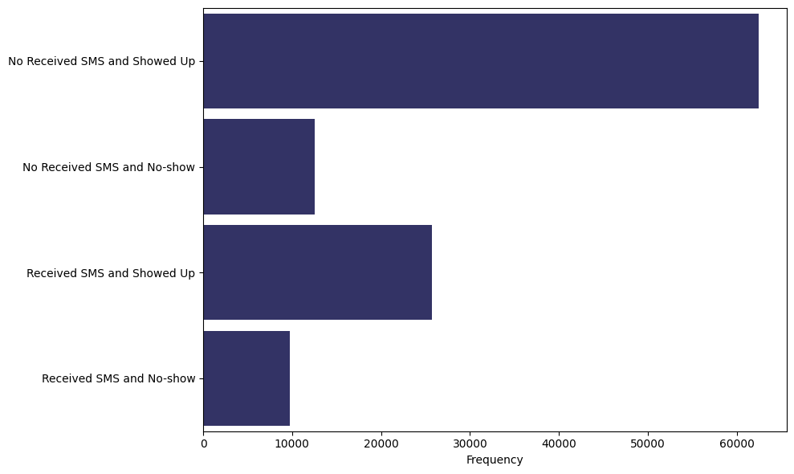

```python
# Filtering the DataFrame for appointments with SMS received
SMS_received_Yes_No_show_Yes = df[(df['SMS_received'] == 1) & df['No-show'].str.contains('Yes')]
SMS_received_Yes_No_Show_No = df[(df['SMS_received'] == 1) & df['No-show'].str.contains('No')]

# Filtering the DataFrame for appointments without SMS received
SMS_received_No_No_show_Yes = df[(df['SMS_received'] == 0) & df['No-show'].str.contains('Yes')]
SMS_received_No_No_Show_No = df[(df['SMS_received'] == 0) & df['No-show'].str.contains('No')]

# Creating data series for the horizontal bar chart
received_yes_show_yes = SMS_received_Yes_No_show_Yes.shape[0]
received_yes_show_no = SMS_received_Yes_No_Show_No.shape[0]
no_received_yes_show_yes = SMS_received_No_No_show_Yes.shape[0]
no_received_no_show_no = SMS_received_No_No_Show_No.shape[0]

# Labels and heights for the bars
labels = ['Received SMS and No-show', 'Received SMS and Showed Up', 'No Received SMS and No-show', 'No Received SMS and Showed Up']
heights = [received_yes_show_yes, received_yes_show_no, no_received_yes_show_yes, no_received_no_show_no]

# Index for bar groups
ind = np.arange(len(labels))

# Full-height bars
width = 0.9

# Creating the turquoise horizontal bar chart
fig, ax = plt.subplots(figsize=(10, 6))
rects = ax.barh(ind, heights, height=width, label='Frequency', color='#333365')

# Adding labels
ax.set_xlabel('Frequency')
ax.set_yticks(ind)
ax.set_yticklabels(labels)

# Adjusting the spacing between bars to occupy the full height
ax.set_ylim(-0.5, len(ind) - 0.5)

# Displaying the chart
plt.tight_layout()
plt.show()
```

### No-show by Neighborhood:

### Question: Which neighborhood has the highest and lowest no-show rates?

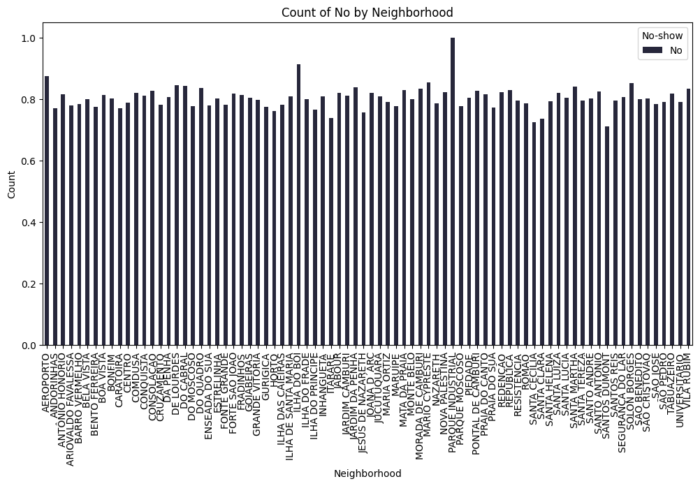

```python
# Calculate NO Rate by neighborhood
no_rate_by_neighborhood = df[df['No-show'] == 'No'].groupby('Neighbourhood').size() / df.groupby('Neighbourhood').size()
no_rate_by_neighborhood = no_rate_by_neighborhood.dropna()

# Plot a stacked bar chart with the specified color
no_rate_by_neighborhood.plot(kind='bar', stacked=True, figsize=(12, 6), color='#27273B')

# Configure title and axis labels
plt.title('Count of No by Neighborhood')
plt.xlabel('Neighborhood')
plt.ylabel('Count')

# Add legend
plt.legend(title='No-show', loc='upper right', labels=['No', 'Yes'])

# Display the chart
plt.show()
```

```python
# Neighborhoods with the highest No-show Rate:
top5_neighborhoods_no_show = no_rate_by_neighborhood.sort_values(ascending=False).head(5)
top5_neighborhoods_no_show
```

```
Neighbourhood
PARQUE INDUSTRIAL    1.000000
ILHA DO BOI          0.914286
AEROPORTO            0.875000
MÁRIO CYPRESTE       0.854447
SOLON BORGES         0.852878
dtype: float64
```

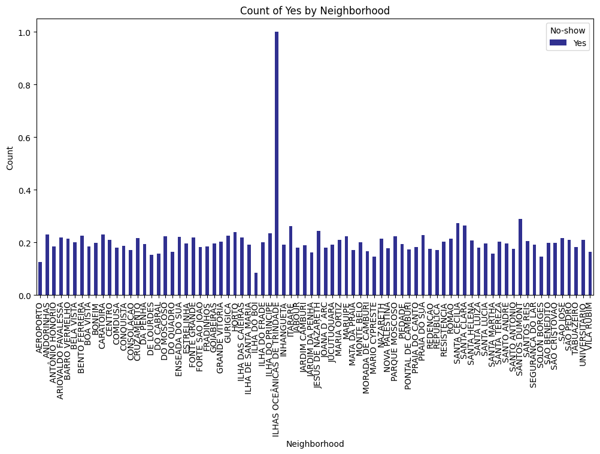

```python
# Find YES Rate by neighborhood
yes_rate_by_neighborhood = df[df['No-show'] == 'Yes'].groupby('Neighbourhood').size() / df.groupby('Neighbourhood').size()
yes_rate_by_neighborhood = yes_rate_by_neighborhood.dropna()

# Plot a stacked bar chart
yes_rate_by_neighborhood.plot(kind='bar', stacked=True, figsize=(12, 6), color="#303090")

# Configure title and axis labels
plt.title('Count of Yes by Neighborhood')
plt.xlabel('Neighborhood')
plt.ylabel('Count')

# Add legend
plt.legend(title='No-show', loc='upper right', labels=['Yes', 'No'])

# Display the chart
plt.show()
```

### Note:

In the case of Ilhas Oceânicas de Trindade, which has an average value of 1, the following chart presents the same visualization without this outlier point.

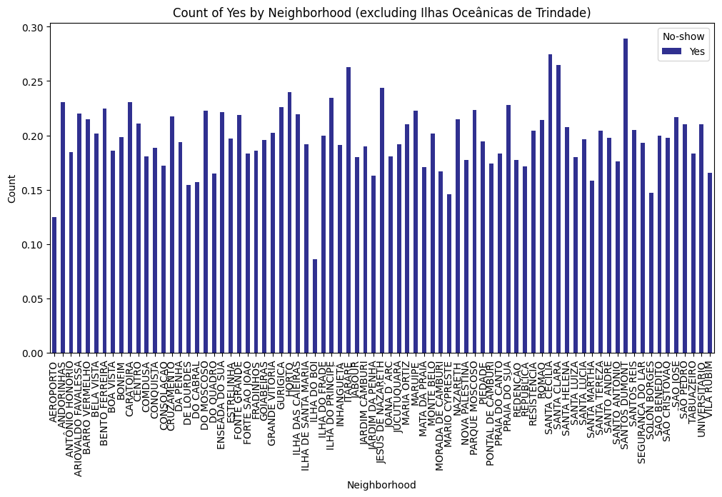

```python
# Find YES Rate by neighborhood excluding 'Ilhas Oceânicas de Trindade'
yes_rate_by_neighborhood = df[df['No-show'] == 'Yes'].loc[df['Neighbourhood'] != 'ILHAS OCEÂNICAS DE TRINDADE'].groupby('Neighbourhood').size() / df.loc[df['Neighbourhood'] != 'ILHAS OCEÂNICAS DE TRINDADE'].groupby('Neighbourhood').size()
yes_rate_by_neighborhood = yes_rate_by_neighborhood.dropna()

# Plot a stacked bar chart
yes_rate_by_neighborhood.plot(kind='bar', stacked=True, figsize=(12, 6), color="#303090")

# Configure title and axis labels
plt.title('Count of Yes by Neighborhood (excluding Ilhas Oceânicas de Trindade)')
plt.xlabel('Neighborhood')
plt.ylabel('Count')

# Add legend
plt.legend(title='No-show', loc='upper right', labels=['Yes', 'No'])

# Display the chart
plt.show()
```

```python
# Top 5 neighborhoods with the highest Yes Rate:
top5_neighborhoods_yes_show = yes_rate_by_neighborhood.sort_values(ascending=False).head(5)
top5_neighborhoods_yes_show
```

[output not shown]

### Note:

These data can be utilized for specific investigations in each of these regions. Whether to comprehend the reasons behind neighborhoods with a higher number of "Yes" achieving this and those with a lower attendance rate, or to understand the factors contributing to this scenario.

### Impact of Time between Scheduling and Appointment

### Question: Is the time gap between scheduling and the actual appointment related to the likelihood of a no-show?

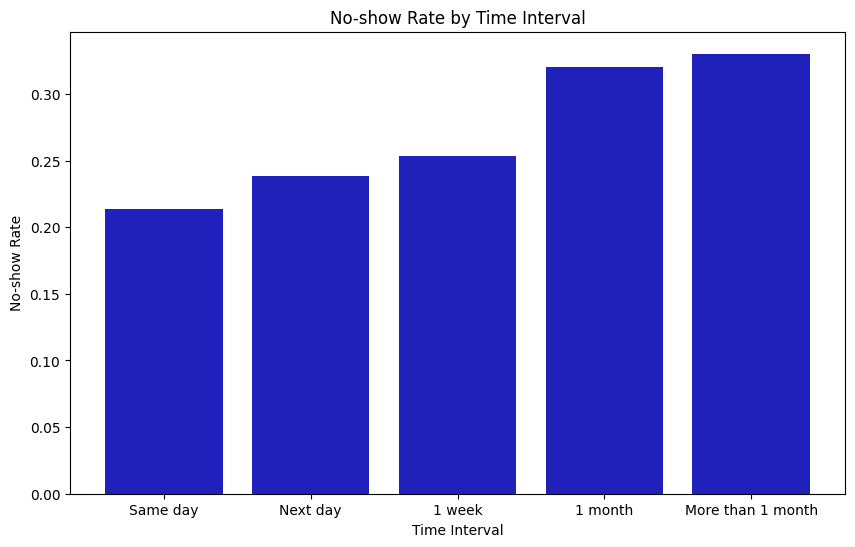

```python
# Converting date columns to datetime format
df['ScheduledDay'] = pd.to_datetime(df['ScheduledDay'])
df['AppointmentDay'] = pd.to_datetime(df['AppointmentDay'])

# Calculating the difference between the scheduling and appointment dates
df['Days_Difference'] = (df['AppointmentDay'] - df['ScheduledDay']).dt.days

# Creating time intervals for analysis
time_intervals = pd.cut(df['Days_Difference'], bins=[-1, 0, 1, 7, 30, 365], labels=['Same day', 'Next day', '1 week', '1 month', 'More than 1 month'])

# Adding the interval column to the DataFrame
df['Time_Interval'] = time_intervals

# Calculating the no-show rate by time interval
no_show_rate_by_time = df[df['No-show'] == 'Yes'].groupby('Time_Interval').size() / df.groupby('Time_Interval').size()

# Displaying the no-show rate by time interval
#print("No-show Rate by Time Interval:")
#print(no_show_rate_by_time)

# Plotting a bar chart for the no-show rate by time interval
plt.figure(figsize=(10, 6))
plt.bar(no_show_rate_by_time.index, no_show_rate_by_time.values, color='#2020BA')

# Configuring title and axis labels
plt.title('No-show Rate by Time Interval')
plt.xlabel('Time Interval')
plt.ylabel('No-show Rate')

# Displaying the chart
plt.show()
```

### Note:

It can be observed that the longer the interval between scheduling and the appointment, the higher the probability of a No-show.

```
Difference: 3.93%
```

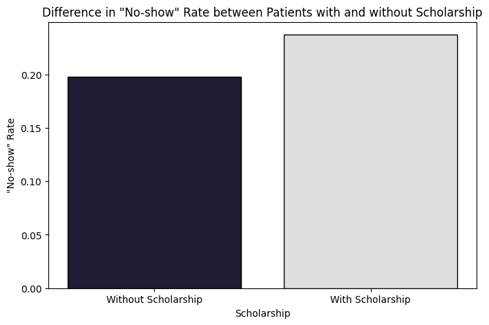

```python
# Calculating the "No-show" rate for each "Scholarship" category
no_show_rate_by_scholarship = df[df['No-show'] == 'Yes'].groupby('Scholarship').size() / df.groupby('Scholarship').size()

# Creating a bar chart with the specified colors
plt.figure(figsize=(8, 5))
bar_colors = ['#1D1D33' if i == 0 else '#DEDEDE' for i in no_show_rate_by_scholarship.index]
plt.bar(no_show_rate_by_scholarship.index, no_show_rate_by_scholarship, color=bar_colors, edgecolor='black')

# Adding labels and legends
plt.title('Difference in "No-show" Rate between Patients with and without Scholarship')
plt.xlabel('Scholarship')
plt.ylabel('"No-show" Rate')
plt.xticks([0, 1], ['Without Scholarship', 'With Scholarship'], rotation=0)

diff_text = f'Difference: {abs(no_show_rate_by_scholarship.diff().iloc[-1]):.2%}'
print(diff_text)

plt.show()
```

### Recurrence of No-show by Patient and its Relation to Health Conditions

### Question: Are there recurring patterns of no-show associated with specific PatientIds, and is this related to specific health conditions?

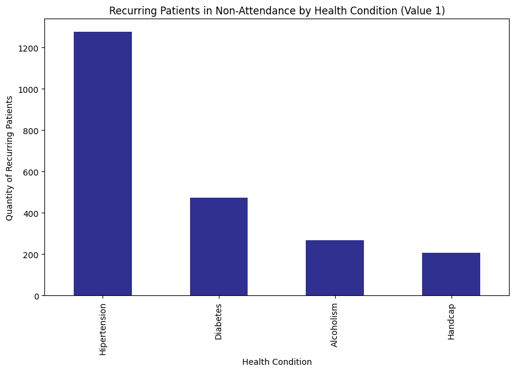

```python
# Identifying cases of non-attendance
no_show_cases = df[df['No-show'] == 'Yes']

# Checking for recurring PatientIds in non-attendance
recurring_patients_no_show = no_show_cases[no_show_cases.duplicated(subset=['PatientId'], keep=False)]

# Obtaining categories of health conditions with value 1
health_conditions = ['Hipertension', 'Diabetes', 'Alcoholism', 'Handcap']
health_conditions_with_value_1 = [condition for condition in health_conditions if recurring_patients_no_show[condition].any() == 1]

# Filtering only relevant columns of the DataFrame
df_filtered = recurring_patients_no_show[health_conditions_with_value_1]

# Counting the quantity of recurring patients in non-attendance for each category
results = df_filtered[health_conditions_with_value_1].sum()

# Creating a bar chart
plt.figure(figsize=(10, 6))
results.plot(kind='bar', color=['#303090'])
plt.title('Recurring Patients in Non-Attendance by Health Condition (Value 1)')
plt.ylabel('Quantity of Recurring Patients')
plt.xlabel('Health Condition')
plt.show()
```

### Note:

The main clinical condition that repeated patients exhibit in not showing up is related to Hypertension. This scenario may be linked to how this clinical condition interferes with personal life. It would be interesting to investigate the more in-depth causes of this point.

### Challenges in Attendance for Patients with Handicap

### Question: Does the presence of a handicap influence the probability of a no-show?

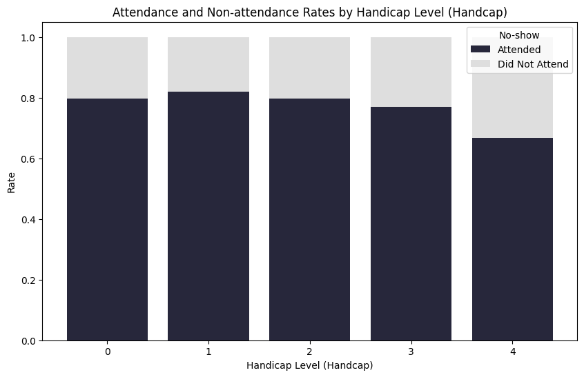

```python
# Calculating the attendance and non-attendance rates by handicap level (Handcap)
attendance_rate = df[df['No-show'] == 'No']['Handcap'].value_counts() / df['Handcap'].value_counts()
non_attendance_rate = df[df['No-show'] == 'Yes']['Handcap'].value_counts() / df['Handcap'].value_counts()

# Creating a single stacked bar chart
plt.figure(figsize=(10, 6))

# Plotting attendance rate
plt.bar(attendance_rate.index, attendance_rate, color='#27273B', label='Attended')

# Plotting non-attendance rate on top of attendance rate
plt.bar(non_attendance_rate.index, non_attendance_rate, bottom=attendance_rate, color='#DEDEDE', label='Did Not Attend')

# Adding labels and legend
plt.title('Attendance and Non-attendance Rates by Handicap Level (Handcap)')
plt.xlabel('Handicap Level (Handcap)')
plt.ylabel('Rate')
plt.legend(title='No-show', loc='upper right', labels=['Attended', 'Did Not Attend'])

# Displaying the chart
plt.show()
```

## Conclusions

### Limitations and Considerations:

- The analysis did not involve robust statistical tests and does not imply definitive conclusions.
- Correlation between variables does not imply causality, and many unexplored factors may influence the results.
- Due to the diversity of Brazil, a vast country, the lack of other specific data may limit more detailed analyses.

### Next Steps:

- A more in-depth investigation is recommended, considering unexplored variables such as socioeconomic data, for a comprehensive understanding.
- Performing additional statistical analyses can provide more precise insights into the observed relationships.